# Statistical Models

# 16 Statistical models

```r
library(tidyverse)
library(dslabs)
library(ggplot2)
```

In this chapter we will demonstrate how poll aggregators collected and combined data reported by different experts to produce improved predictions. We will introduce ideas behind the statistical models that were used by poll aggregators to improve election forecasts beyond the power of individual polls.

## 16.1 Poll aggregators

A few weeks before the 2012 election Nate Silver was giving Obama a 90% chance of winning. We will use a Monte Carlo simulation to illustrate the insight Mr. Silver had and others missed. To do this, we generate results for 12 polls taken the week before the election. We mimic sample sizes from actual polls and construct and report 95% confidence intervals for each of the 12 polls.

```r
d <- 0.039
Ns <- c(1298, 533, 1342, 897, 774, 254, 812, 324, 1291, 1056, 2172, 516)
p <- (d + 1) / 2

polls <- map_df(Ns, function(N) {
  x <- sample(c(0,1), size=N, replace=TRUE, prob=c(1-p, p))
  x_hat <- mean(x)
  se_hat <- sqrt(x_hat * (1 - x_hat) / N)
  list(x_hat = x_hat, estimate = 2 * x_hat - 1, se_hat = se_hat,
    low = 2*(x_hat - 1.96*se_hat) - 1,
    high = 2*(x_hat + 1.96*se_hat) - 1,
    sample_size = N)
}) %>% mutate(poll = seq_along(Ns))
```

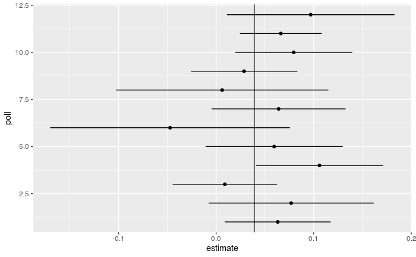

```r
polls %>%
  ggplot(aes(poll, y=estimate)) +
  geom_linerange(aes(ymin=low, ymax=high)) +
  geom_point() +
  geom_hline(aes(yintercept = d)) +
  coord_flip()
```

```r
sum(polls$sample_size)
```

```
[1] 11269
```

```r
d_hat <- polls %>%
  summarize(avg = sum(estimate*sample_size) / sum(sample_size)) %>%
  pull(avg)
```

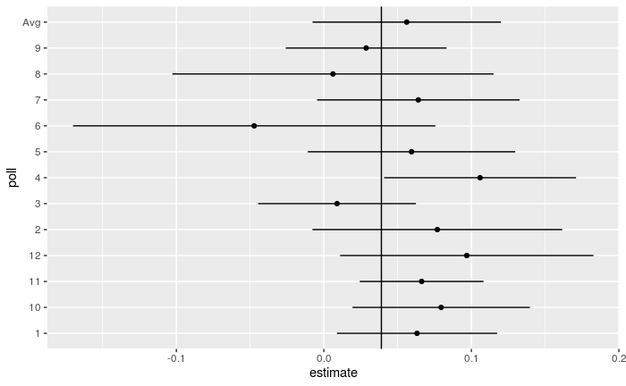

```r
x_bar <- polls %>%
  summarize(
    sum(x_hat * sample_size)/sum(sample_size)) %>% .[[1]]

se_hat <- polls %>%
  summarize(
    sqrt(sum(se_hat^2*sample_size/sum(sample_size)))) %>% .[[1]]

N <- polls %>% summarize(sum(sample_size)) %>% .[[1]]

polls <- rbind(polls, data.frame(x_hat = x_bar,
                        se_hat = se_hat,
                        estimate = 2 * x_bar - 1,
                        low = 2*(x_bar - 1.96*se_hat) - 1,
                        high = 2*(x_bar + 1.96*se_hat) - 1,
                        sample_size = N,
                        poll = 'Avg'
                        ))

polls %>%
  ggplot(aes(poll, y=estimate)) +
  geom_linerange(aes(ymin=low, ymax=high)) +
  geom_point() +
  geom_hline(aes(yintercept = d)) +
  coord_flip()
```

### 16.1.1 Poll data

We use public polling data organized by FiveThirtyEight for the 2016 presidential election. The data is included as part of the dslabs package:

```r
data(polls_us_election_2016)
```

For this first example, we will filter the data to include national polls conducted during the week before the election. We also remove polls that FiveThirtyEight has determined not to be reliable and graded with a “B” or less. Some polls have not been graded and we include those:

```r
polls <- polls_us_election_2016 %>%
  filter(state == "U.S." & enddate >= "2016-10-31" &
           (grade %in% c("A+","A","A-","B+") | is.na(grade)))
```

We add a spread estimate:

```r
polls <- polls %>%
  mutate(spread = rawpoll_clinton/100 - rawpoll_trump/100)
```

For this example, we will assume that there are only two parties and call p the proportion voting for Clinton and 1-p the proportion voting for Trump. We are interested in the spread 2p-1. Let’s call the spread d(for difference). We have 49 estimates of the spread. The theory we learned tells us that these estimates are a random variable with a probability distribution that is approximately normal. The expected value is the election night spread d and the standard error is $2\sqrt{\frac{p(1-p)}{N}}$. Assuming the urn model we described earlier is a good one, we can use this information to construct a confidence interval based on the aggregated data. The estimated spread is:

```r
d_hat <- polls %>%
  summarize(d_hat = sum(spread * samplesize) / sum(samplesize)) %>%
  pull(d_hat)
```

and the standard error is:

```r
p_hat <- (d_hat+1)/2
moe <- 1.96 * 2 * sqrt(p_hat * (1 - p_hat) / sum(polls$samplesize))
moe
```

```
[1] 0.006623178
```

So we report a spread of 1.43% with a margin of error of 0.66%. On election night, we discover that the actual percentage was 2.1%, which is outside a 95% confidence interval. What happened?

A histogram of the reported spreads shows a problem:

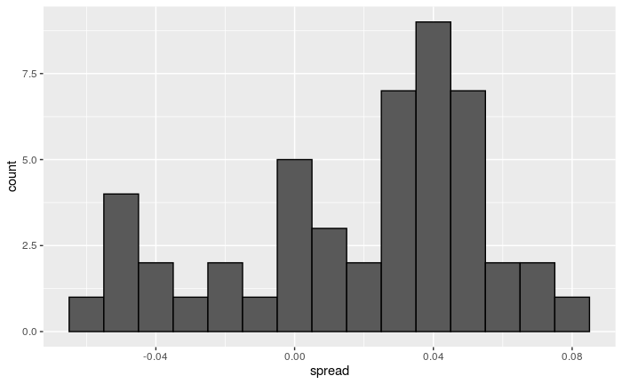

```r
polls %>%
  ggplot(aes(spread)) +
  geom_histogram(color="black", binwidth = .01)
```

The data does not appear to be normally distributed and the standard error appears to be larger than 0.007. The theory is not quite working here.

### 16.1.2 Pollster bias

Notice that various pollsters are involved and some are taking several polls a week:

```r
polls %>% group_by(pollster) %>% summarize(n())
```

| pollster | n() |
| --- | --- |
| ABC News/Washington Post | 7 |
| Angus Reid Global | 1 |
| CBS News/New York Times | 2 |
| Fox News/Anderson Robbins Research/Shaw & Company Research | 2 |
| IBD/TIPP | 8 |
| Insights West | 1 |
| Ipsos | 6 |
| Marist College | 1 |
| Monmouth University | 1 |
| Morning Consult | 1 |

[output cut: 5 more lines]

Let’s visualize the data for the pollsters that are regularly polling:

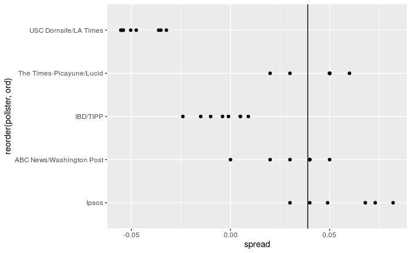

```r
pollsters <- polls %>%
  group_by(pollster) %>%
  summarize(ord = sum(!is.na(pollster))) %>%
  filter(ord >= 5) %>% .$pollster
k <- polls %>% group_by(pollster) %>% summarize(ord = sum(!is.na(pollster)))
polls %>%
  merge(k, key = pollster, how = "inner") %>%
  filter(pollster %in% pollsters) %>%
  ggplot() +
  geom_point(aes(x=spread, y = reorder(pollster, ord))) +
  geom_vline(xintercept=d)
```

This plot reveals an unexpected result. First, consider that the standard error predicted by theory for each poll:

```r
polls %>% group_by(pollster) %>%
  filter(n() >= 6) %>%
  summarize(se = 2 * sqrt(p_hat * (1-p_hat) / median(samplesize)))
```

| pollster | se |
| --- | --- |
| ABC News/Washington Post | 0.02654389 |
| IBD/TIPP | 0.03332069 |
| Ipsos | 0.02251943 |
| The Times-Picayune/Lucid | 0.01963986 |
| USC Dornsife/LA Times | 0.01831826 |

is between 0.018 and 0.033, which agrees with the within poll variation we see. However, there appears to be differences across the polls. Note, for example, how the USC Dornsife/LA Times pollster is predicting a 4% win for Trump, while Ipsos is predicting a win larger than 5% for Clinton. The theory we learned says nothing about different pollsters producing polls with different expected values. All the polls should have the same expected value. FiveThirtyEight refers to these differences as “house effects”. We also call them pollster bias.

In the following section, rather than use the urn model theory, we are instead going to develop a data-driven model.

## 16.2 Data-driven models

For each pollster, let’s collect their last reported result before the election:

```r
one_poll_per_pollster <- polls %>% group_by(pollster) %>%
  filter(enddate == max(enddate)) %>%
  ungroup()
```

Here is a histogram of the data for these 15 pollsters:

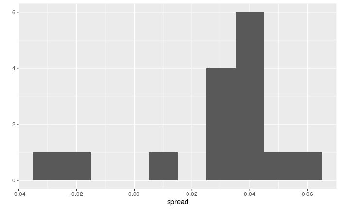

```r
qplot(spread, data = one_poll_per_pollster, binwidth = 0.01)
```

```r
sd(one_poll_per_pollster$spread)
```

```
[1] 0.02419369
```

We are now ready to form a new confidence interval based on our new data-driven model:

```r
results <- one_poll_per_pollster %>%
  summarize(avg = mean(spread),
            se = sd(spread) / sqrt(length(spread))) %>%
  mutate(start = avg - 1.96 * se,
         end = avg + 1.96 * se)
round(results * 100, 1)
```

| avg | se | start | end |
| --- | --- | --- | --- |
| 2.9 | 0.6 | 1.7 | 4.1 |

Our confidence interval is wider now since it incorporates the pollster variability. It does include the election night result of 2.1%. Also, note that it was small enough not to include 0, which means we were confident Clinton would win the popular vote.

Are we now ready to declare a probability of Clinton winning the popular vote? Not yet. In our model d is a fixed parameter so we can’t talk about probabilities. To provide probabilities, we will need to learn about Bayesian statistics.

## 16.3 Exercises

We have been using urn models to motivate the use of probability models. Most data science applications are not related to data obtained from urns. More common are data that come from individuals. The reason probability plays a role here is because the data come from a random sample. The random sample is taken from a population and the urn serves as an analogy for the population.

Let’s revisit the heights dataset. Suppose we consider the males in our course the population.

```r
data(heights)
x <- heights %>% filter(sex == "Male") %>%
  pull(height)
```

1. Mathematically speaking, `x` is our population. Using the urn analogy, we have an urn with the values of `x` in it. What are the average and standard deviation of our population?

```r
mean_x = mean(x)
mean_x
```

```
[1] 69.31475
```

```r
sd_x = sd(x)
sd_x
```

```
[1] 3.611024
```

2. Call the population average computed above μ and the standard deviation σ. Now take a sample of size 50, with replacement, and construct an estimate for μ and σ.

```r
N=50
est <- function(){
  mean(sample(x, N, replace = T))
}
sam <- replicate(100, est())
mean(sam)
```

```
[1] 69.42165
```

```r
sd(sam)
```

```
[1] 0.4960695
```

```r
sam <- replicate(200, est())
mean(sam)
```

```
[1] 69.35401
```

```r
sd(sam)
```

```
[1] 0.4782345
```

3. What does the theory tell us about the sample average $\bar X$ and how it is related to μ? b
1. It is practically identical to μ.
2. It is a random variable with expected value μ and standard error σ/√N.
3. It is a random variable with expected value μ and standard error σ.
4. Contains no information.
4. So how is this useful? We are going to use an oversimplified yet illustrative example. Suppose we want to know the average height of our male students, but we only get to measure 50 of the 708. We will use $\bar X$ as our estimate. We know from the answer to exercise 3 that the standard estimate of our error $\bar X−μ$ is σ/√N. We want to compute this, but we don’t know σ. Based on what is described in this section, show your estimate of σ.

```r
sam <- replicate(100, est())
x_bar <- mean(sam)
x_bar
```

```
[1] 69.35128
```

```r
sd <- sd(sam)
sd
```

```
[1] 0.5252824
```

```r
sigma = sd * sqrt(N)
sigma
```

```
[1] 3.714307
```

5. Now that we have an estimate of σ, let’s call our estimate s. Construct a 95% confidence interval for μ.

```r
c(x_bar-1.96*sigma, x_bar+1.96*sigma)
```

```
[1] 62.07124 76.63132
```

6. Now run a Monte Carlo simulation in which you compute 10,000 confidence intervals as you have just done. What proportion of these intervals include μ?

```r
B = 10000
try <- 1:B
interval <- map_df(try, function(try) {
  ga <- sample(x, N, replace = T)
  x_hat <- mean(ga)
  se_hat <- sd(ga)
  list(mean = x_hat, se = se_hat,
    low = x_hat - 1.96*se_hat,
    high = x_hat + 1.96*se_hat)
}) %>% mutate(try = seq_along(try))

interval %>% summarize(mean(mean_x > low && mean_x < high))
```

| mean(mean_x > low && mean_x < high) |
| --- |
| 1 |

7. In this section, we talked about pollster bias. We used visualization to motivate the presence of such bias. Here we will give it a more rigorous treatment. We will consider two pollsters that conducted daily polls. We will look at national polls for the month before the election.

```r
data(polls_us_election_2016)
polls <- polls_us_election_2016 %>%
  filter(pollster %in% c("Rasmussen Reports/Pulse Opinion Research",
                         "The Times-Picayune/Lucid") &
           enddate >= "2016-10-15" &
           state == "U.S.") %>%
  mutate(spread = rawpoll_clinton/100 - rawpoll_trump/100)
```

We want to answer the question: is there a poll bias? Make a plot showing the spreads for each poll.

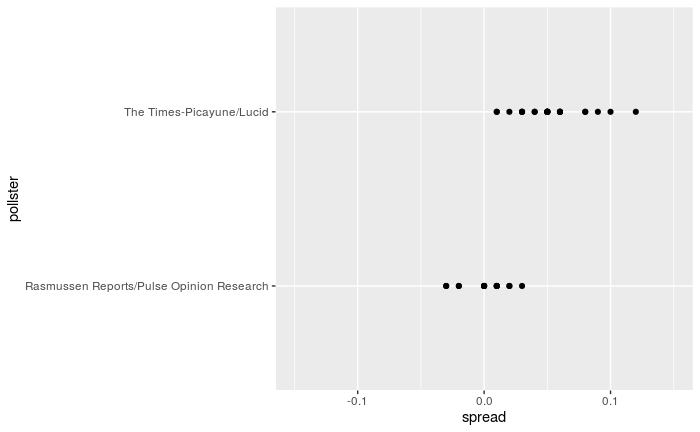

```r
ggplot(polls) +
  geom_point(aes(x=spread, y=pollster)) +
  lims(x=c(-0.15, 0.15))
```

8. The data does seem to suggest there is a difference. However, these data are subject to variability. Perhaps the differences we observe are due to chance.

The urn model theory says nothing about pollster effect. Under the urn model, both pollsters have the same expected value: the election day difference, that we call d.

To answer the question “is there an urn model?”, we will model the observed data $Y_{i,j}$

in the following way:
$$Y_{i,j}=d+b_i+\epsilon_{i,j}$$
with i=1, 2 indexing the two pollsters,$b_i$ the bias for pollster i and $\epsilon_{i,j}$ poll to poll chance variability. We assume the ε are independent from each other, have expected value 0 and standard deviation $\sigma_i$ regardless of j.

Which of the following best represents our question? c

1. Is $\epsilon_{i,j} = 0$?
2. How close are the $Y_{i,j}$ to d?
3. Is $b_1\neq b_2$?
4. Are $b_1=0$ and $b_2=0$?
9. In the right side of this model only $\epsilon_{i,j}$ is a random variable. The other two are constants. What is the expected value of $Y_{1,j}$?
   $$d+b_1$$
10. Suppose we define $\bar{Y_1}$ as the average of poll results from the first poll, $Y_{1,1},\cdots,Y_{1,N_1}$ with $N_1$ the number of polls conducted by the first pollster:

```r
N_1 <- polls %>%
  filter(pollster=="Rasmussen Reports/Pulse Opinion Research") %>%
  summarize(N_1 = n()) %>%
  pull(N_1)
N_1
```

```
[1] 16
```

What is the expected values $\bar{Y_1}$?

```r
Y_1_bar <- polls %>%
  filter(pollster=="Rasmussen Reports/Pulse Opinion Research") %>%
  summarize(E = mean(spread)) %>%
  pull(E)
Y_1_bar
```

```
[1] 0.000625
```

11. What is the standard error of $\bar{Y_1}$?

```r
se1 <- polls %>%
  filter(pollster=="Rasmussen Reports/Pulse Opinion Research") %>%
  summarize(se = sd(spread)) %>%
  pull(se)
se1
```

```
[1] 0.01768945
```

12. Suppose we define $\bar{Y_2}$ as the average of poll results from the first poll, $Y_{2,1},\cdots,Y_{2,N_2}$ with $N_2$ the number of polls conducted by the first pollster. What is the expected value $\bar{Y_2}$?

```r
N_2 <- polls %>%
  filter(pollster=="The Times-Picayune/Lucid") %>%
  summarize(N_2 = n()) %>%
  pull(N_2)
Y_2_bar <- polls %>%
  filter(pollster=="The Times-Picayune/Lucid") %>%
  summarize(E = mean(spread)) %>%
  pull(E)
N_2
```

```
[1] 24
```

```r
Y_2_bar
```

```
[1] 0.05291667
```

13. What is the standard error of $\bar{Y_2}$?

```r
se2 <- polls %>%
  filter(pollster=="The Times-Picayune/Lucid") %>%
  summarize(se = sd(spread)) %>%
  pull(se)
se2
```

```
[1] 0.02678078
```

14. Using what we learned by answering the questions above, what is the expected value of $\bar{Y_2}-\bar{Y_1}$?

```r
mean_Y_dif = Y_2_bar - Y_1_bar
mean_Y_dif
```

```
[1] 0.05229167
```

15. Using what we learned by answering the questions above, what is the standard error of $\bar{Y_2}-\bar{Y_1}$?

```r
se_Y_dif = sqrt(se1^2/N_1+se2^2/N_2)
se_Y_dif
```

```
[1] 0.007031433
```

16. The answer to the question above depends on $\sigma_1$ and $\sigma_2$, which we don’t know. We learned that we can estimate these with the sample standard deviation. Write code that computes these two estimates.
17. What does the CLT tell us about the distribution of $\bar{Y_2}-\bar{Y_1}$? c
1. Nothing because this is not the average of a sample.
2. Because the $Y_{i,j}$ are approximately normal, so are the averages.
3. Note that $\bar{Y_2}$ and $\bar{Y_1}$ are sample averages, so if we assume $N_1$ and $N_2$ are large enough, each is approximately normal. The difference of normals is also normal.
4. The data are not 0 or 1, so CLT does not apply.
18. We have constructed a random variable that has expected value $b_2-b_1$, the pollster bias difference. If our model holds, then this random variable has an approximately normal distribution and we know its standard error. The standard error depends on $\sigma_1$ and $\sigma_2$, but we can plug the sample standard deviations we computed above. We started off by asking: is $b_2-b_1$ different from 0? Use all the information we have learned above to construct a 95% confidence interval for the difference $b_2$ and $b_1$.

```r
c(mean_Y_dif-1.96*se_Y_dif,
  mean_Y_dif+1.96*se_Y_dif)
```

```
[1] 0.03851006 0.06607328
```

19. The confidence interval tells us there is relatively strong pollster effect resulting in a difference of about 5%. Random variability does not seem to explain it. We can compute a p-value to relay the fact that chance does not explain it. What is the p-value?

```r
pnorm(0, mean_Y_dif, se_Y_dif)
```

```
[1] 5.155974e-14
```

20. The statistic formed by dividing our estimate of $b_2-b_1$ by its estimated standard error:
    $$\frac{\bar{Y_2}-\bar{Y_1}}{\sqrt{\frac{s_2^2}{N_2}+\frac{s_1^2}{N_1}}}$$
    is called the t-statistic. Now notice that we have more than two pollsters. We can also test for pollster effect using all pollsters, not just two. The idea is to compare the variability across polls to variability within polls. We can actually construct statistics to test for effects and approximate their distribution. The area of statistics that does this is called Analysis of Variance or ANOVA. We do not cover it here, but ANOVA provides a very useful set of tools to answer questions such as: is there a pollster effect?

For this exercise, create a new table:

```r
polls <- polls_us_election_2016 %>%
  filter(enddate >= "2016-10-15" &
           state == "U.S.") %>%
  group_by(pollster) %>%
  filter(n() >= 5) %>%
  mutate(spread = rawpoll_clinton/100 - rawpoll_trump/100) %>%
  ungroup()
```

Compute the average and standard deviation for each pollster and examine the variability across the averages and how it compares to the variability within the pollsters, summarized by the standard deviation.

```r
pls <- polls %>%
  group_by(pollster) %>%
  summarize(E = mean(spread), SE = sd(spread), N = n())
pls
```

| pollster | E | SE | N |
| --- | --- | --- | --- |
| ABC News/Washington Post | 0.037333333 | 0.033904628 | 15 |
| CVOTER International | 0.027895455 | 0.017975499 | 22 |
| Google Consumer Surveys | 0.030280000 | 0.018476390 | 5 |
| Gravis Marketing | 0.016000000 | 0.015165751 | 5 |
| IBD/TIPP | 0.001047619 | 0.016832933 | 21 |
| Ipsos | 0.055272727 | 0.019464698 | 22 |
| Morning Consult | 0.041428571 | 0.014638501 | 7 |
| Rasmussen Reports/Pulse Opinion Research | 0.000625000 | 0.017689451 | 16 |
| The Times-Picayune/Lucid | 0.052916667 | 0.026780779 | 24 |
| USC Dornsife/LA Times | -0.021320833 | 0.020661474 | 24 |

[output cut: 1 more lines]

```r
E_tot <- pls %>%
  summarize(E= mean(E)) %>%
  pull(E)
E_tot
```

```
[1] 0.02557078
```

```r
SE_tot <- pls %>% summarize(SE = sqrt(sum(SE^2/N))) %>% pull(SE)
SE_tot
```

```
[1] 0.01855243
```

```r
c(E_tot-1.96*SE_tot,
  E_tot+1.96*SE_tot)
```

```
[1] -0.01079198  0.06193353
```

it contains 0. So, we would not deny the Null hypothesis.